# Analysis on Cyclistic Bike-Share 10 months data

Uche

10/17/2021

# **Loading packages**

```r
library(tidyverse)
library(lubridate)
```

```r
library(ggplot2)
```

# ** Importing data

Note: The code below combines the monthly data frames into a full_year data frame

Note: The code below creates a new data frame with specified columns

Note: The code below cleans the data and adds new columns

Note: The code below converts ride_length from factor to numeric

Note: The code below sieves data with negative ride_length

Note: The code below performs general summary descriptive analysis

```
##    ride_id          rideable_type        started_at
##  Length:4486974     Length:4486974     Min.   :2020-12-01 00:01:15
##  Class :character   Class :character   1st Qu.:2021-05-19 20:42:30
##  Mode  :character   Mode  :character   Median :2021-07-05 18:36:57
##                                        Mean   :2021-06-25 11:47:06
##                                        3rd Qu.:2021-08-17 17:38:54
##                                        Max.   :2021-09-30 23:59:48
##     ended_at                   member_casual           date
##  Min.   :2020-12-01 00:06:33   Length:4486974     Min.   :2020-12-01
##  1st Qu.:2021-05-19 21:05:01   Class :character   1st Qu.:2021-05-19
##  Median :2021-07-05 19:04:36   Mode  :character   Median :2021-07-05
##  Mean   :2021-06-25 12:10:15                      Mean   :2021-06-24
##  3rd Qu.:2021-08-17 17:56:44                      3rd Qu.:2021-08-17
##  Max.   :2021-10-01 22:55:35                      Max.   :2021-09-30
##     month               day                year           day_of_week
##  Length:4486974     Length:4486974     Length:4486974     Length:4486974
##  Class :character   Class :character   Class :character   Class :character
##  Mode  :character   Mode  :character   Mode  :character   Mode  :character
##
##
##
##   ride_length
##  Min.   :      1
##  1st Qu.:    432
##  Median :    765
##  Mean   :   1389
##  3rd Qu.:   1382
##  Max.   :3356649
```

Note: The code below performs descriptive analysis that shows average_ride_length for member_casual

```
## # A tibble: 2 x 2
##   member_casual mean_ride_length
##   <chr>                    <dbl>
## 1 casual                   1984.
## 2 member                    853.
```

Note: The code below performs summary statistics for ride_length

```
##    Min. 1st Qu.  Median    Mean 3rd Qu.    Max.
##       1     432     765    1389    1382 3356649
```

Note: The code below performs descriptive analysis for each month for average_ride length and member_casual

```
## # A tibble: 20 x 3
## # Groups:   month [10]
##    month member_casual mean_ride_length
##    <chr> <chr>                    <dbl>
##  1 01    casual                   1541.
##  2 01    member                    772.
##  3 02    casual                   2963.
##  4 02    member                   1081.
##  5 03    casual                   2290.
##  6 03    member                    838.
##  7 04    casual                   2282.
##  8 04    member                    881.
##  9 05    casual                   2294.
## 10 05    member                    878.
## 11 06    casual                   2228.
## 12 06    member                    881.
## 13 07    casual                   1968.
## 14 07    member                    854.
## 15 08    casual                   1727.
## 16 08    member                    846.
## 17 09    casual                   1669.
## 18 09    member                    824.
## 19 12    casual                   1611.
## 20 12    member                    765.
```

Note: The code below arranges the order of the day_of_the_week

Note: The code below makes different plots Note: make a plot of number of rides for each day of the week

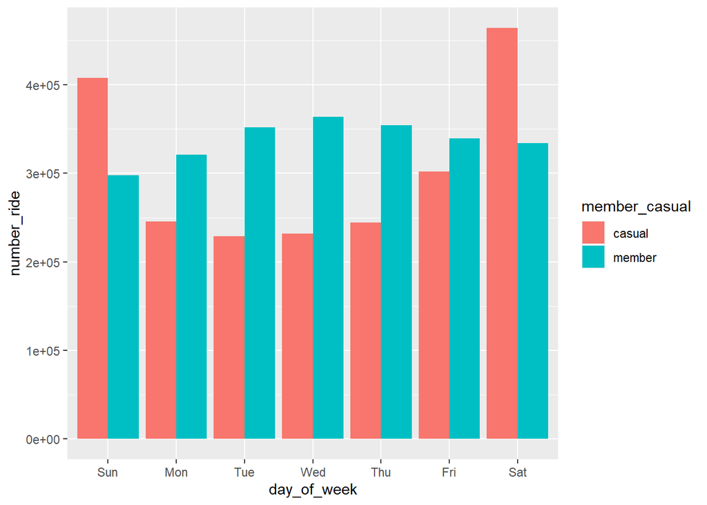

Note: make a plot of number of rides and ride_length for each day of the week

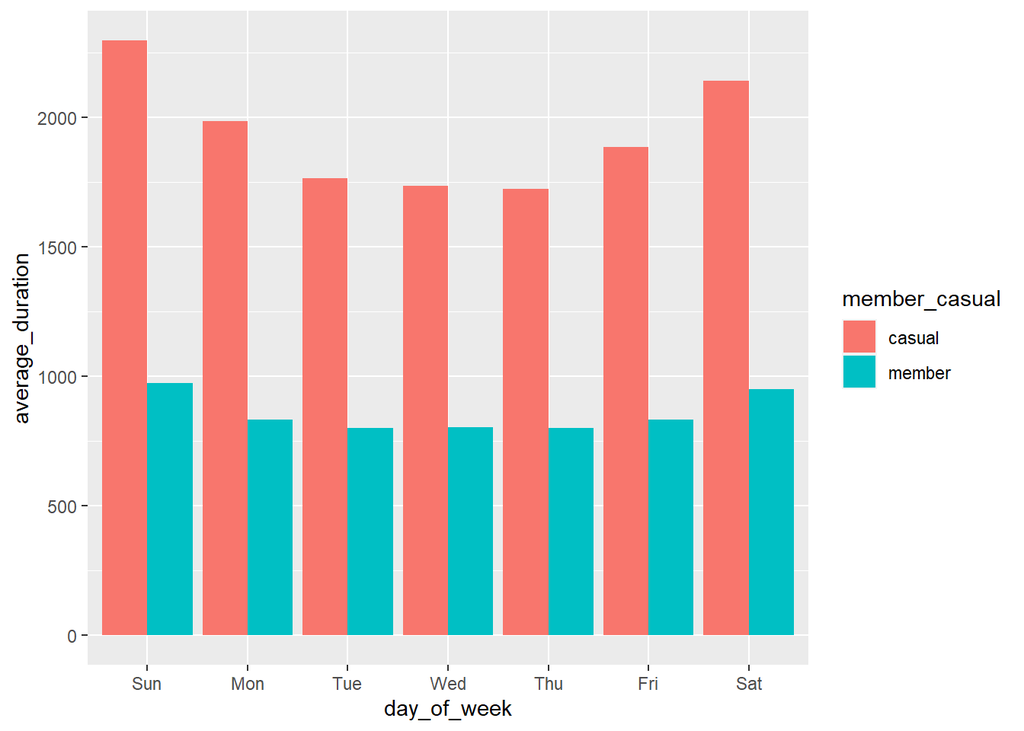

Note: make a plot of number of rides and average ride_length for each month

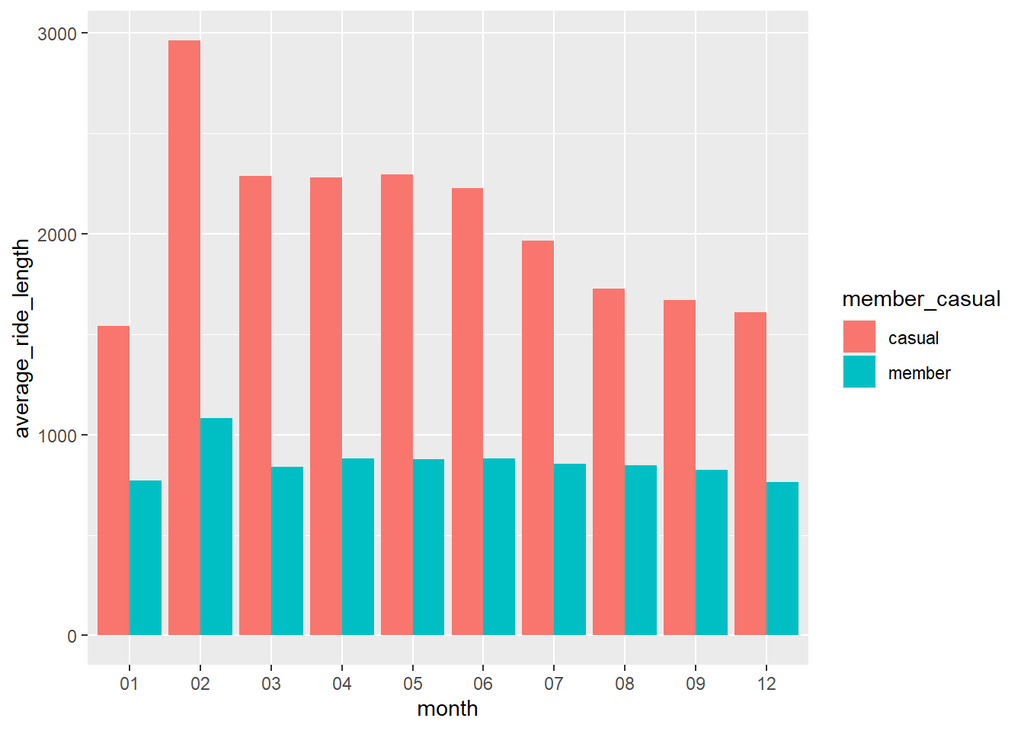

Note: make a plot of number of rides for each month

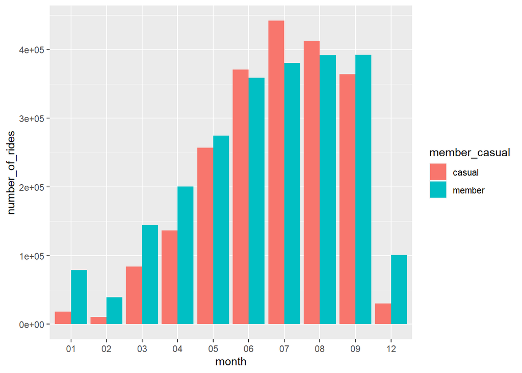

Note: The code below creates new data frames for export Note: Average ride length for casual and members for each day of the week

Note: Average ride length for casual and members for each month

Note: Average number of rides for casual and members for each day of the week

Note: Average ride length for casual and members for each month

Note: The code below exports csv files